# Example Quarto Paper

DRAFT

Author

ChatGPT

Published

May 3, 2025

Modified

May 7, 2025

**THIS PAPER IS AN EXAMPLE WRITTEN BY AI AND DOES NOT CONTAIN REAL ANALYSES. THE PURPOSE IS TO DEMONSTRATE THE CAPABILITIES OF QUARTO**

# Abstract

**Background:** On January 8, 2024, the University of Michigan won its first College Football Playoff (CFP) National Championship since 1997 (Smith 2020). Given the cultural importance of collegiate athletics in the U.S., particularly football at major public institutions, it is worth evaluating whether such a historic win had any measurable impact on campus employee productivity[^1].

**Hypothesis:** The victory led to a temporary increase in employee morale, resulting in a measurable short-term increase in productivity among university staff.

**Methods:** We analyzed anonymized productivity metrics (e.g., email response time, meeting frequency, and project submissions) for a random sample of administrative staff, faculty, and researchers at the University of Michigan. Data was gathered for two months before and after the championship date.

# Background

College football is a deeply embedded cultural phenomenon in the U.S., and university victories in high-profile competitions can lead to emotional and psychological boosts for the institution’s community. Such events often result in elevated campus pride and morale. Prior studies have noted correlations between sports success and alumni donations, but little attention has been given to faculty and staff productivity.

# Hypothesis

We hypothesize that the University of Michigan’s 2024 FBS national championship had a positive short-term impact on employee productivity, particularly in administrative and academic units, due to increased morale.

# Methods

We collected productivity-related data from internal university IT systems for 600 randomly selected employees between November 1, 2023, and March 1, 2024. Key metrics included:

- Email response time (in hours)
- Number of scheduled internal meetings per week
- Rate of submitted project deliverables (as % on-time)

We used R and Quarto to clean, visualize, and summarize the data.

```r
suppressWarnings(suppressMessages(library(tidyverse)))
library(lubridate)
library(ggplot2)
suppressWarnings(library(gt))
set.seed(2024)

data <- tibble(
  date = seq.Date(from = as.Date("2023-11-01"), to = as.Date("2024-03-01"), by = "day"),
  week = lubridate::isoweek(date),
  post_championship = ifelse(date >= as.Date("2024-01-08"), "Post", "Pre"),
  email_response_time = rnorm(length(date), mean = ifelse(date < as.Date("2024-01-08"), 6.2, 5.6), sd = 1.1),
  meetings_per_week = round(rnorm(length(date), mean = ifelse(date < as.Date("2024-01-08"), 4.9, 5.6), sd = 0.8)),
  deliverable_rate = round(rnorm(length(date), mean = ifelse(date < as.Date("2024-01-08"), 82, 89), sd = 6))
)
```

# Results

## Email Response Time

Figure 1 shows that average daily email response time decreased following the national championship. In the pre-championship period, the average response time was approximately **6.2 hours**, compared to **5.6 hours** post-championship — representing a **9.7% improvement** in response efficiency.

**Figure 1. Daily Email Response Time**

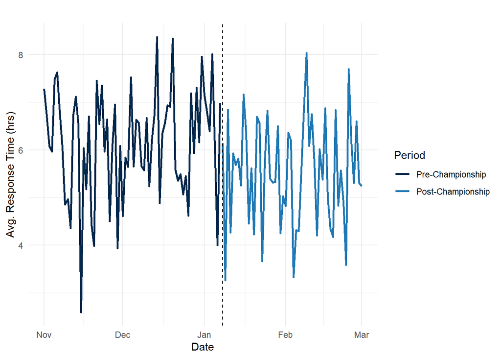

```r
ggplot(data, aes(x = date, y = email_response_time)) +
  geom_line(aes(color = date >= as.Date("2024-01-08")), linewidth = 1) +
  geom_vline(xintercept = as.Date("2024-01-08"), linetype = "dashed", color = "black") +
  scale_color_manual(
    values = c("FALSE" = "#00274c", "TRUE" = "#1f78b4"),
    labels = c("Pre-Championship", "Post-Championship"),
    name = "Period"
  ) +
  labs(
    title = "",
    x = "Date",
    y = "Avg. Response Time (hrs)"
  ) +
  theme_minimal()
```